# Introduction to Python Project : FoodHub Data Analysis

# Observations

1) food_preparation_time: minumum time to prepare the food is 20 minutes, average time to prepare food is 27 minutes, maximum time to prepare the food is 35 minutes.  
2) cost_of_the_order: Below are cost of the food order price: minimum - 4.47 average - 14.4 maximum - 35.7 most foods are sold between 12 rs to 17 rs.  
3) delivery_time: Below are time taken to delivery the food: minimum - 15 minutes average - 25 minutes maximum - 33 minuetes, overall it is right skewed, means most of the foods are deliveries are fast and few take long.

4) rating: Below are the ratings given to each category of orders: Not given - 38.78% 5 - 30.98% 4 - 20.34% 3 - 9.91%

5) cuisine_type: As per count plot, Among the top cuisines, American has the highest number of orders, followed by Japanese, Italian, and Chinese. Other cuisine types have fewer orders in comparison to these top categories.

6)day_of_the_week: As per the count plot, the majority of orders occur during the weekends, indicating higher customer activity on weekends compared to weekdays.

8) order_id : it is just an identifier, do not provider a meaningful insights out of it when we plot them individually.

9) customer_id: Large peak between 40,000 and 150,000 indicating a large group of earlier customers. and second smaller peak between 320,000 and 400,000 suggesting a newer wave of customers. in between these two groups (around 150,000 to 300,000), there's a significant dip in customer count, showing lower customer acquisition or engagement during that period.

### **Question 7**: Which are the top 5 restaurants in terms of the number of orders received? [1 mark]

```python
# Write the code here
df['restaurant_name'].value_counts().head(5)
```

| restaurant_name | count |
| --- | --- |
| Shake Shack | 219 |
| The Meatball Shop | 132 |
| Blue Ribbon Sushi | 119 |
| Blue Ribbon Fried Chicken | 96 |
| Parm | 68 |

**dtype:** int64

#### Observations:

Shake Shack, The Meatball Shop, Blue Ribbon Sushi, Blue Ribbion Fried Chicken, Parm are the top five restaurants in terms of the number of orders received

### **Question 8**: Which is the most popular cuisine on weekends? [1 mark]

```python
# Write the code here
df.groupby(['cuisine_type', 'day_of_the_week']).size()
```

| cuisine_type | day_of_the_week | 0 |
| --- | --- | --- |
| American | Weekday | 169 |
|  | Weekend | 415 |
| Chinese | Weekday | 52 |
|  | Weekend | 163 |
| French | Weekday | 5 |
|  | Weekend | 13 |
| Indian | Weekday | 24 |
|  | Weekend | 49 |
| Italian | Weekday | 91 |
|  | Weekend | 207 |
| Japanese | Weekday | 135 |
|  | Weekend | 335 |
| Korean | Weekday | 2 |
|  | Weekend | 11 |
| Mediterranean | Weekday | 14 |
|  | Weekend | 32 |
| Mexican | Weekday | 24 |
|  | Weekend | 53 |
| Middle Eastern | Weekday | 17 |
|  | Weekend | 32 |
| Southern | Weekday | 6 |
|  | Weekend | 11 |
| Spanish | Weekday | 1 |
|  | Weekend | 11 |
| Thai | Weekday | 4 |
|  | Weekend | 15 |
| Vietnamese | Weekday | 3 |
|  | Weekend | 4 |

**dtype:** int64

#### Observations:

**American** Cuisine_type is the most popular cuisine on weekends.

### **Question 9**: What percentage of the orders cost more than 20 dollars? [2 marks]

```python
# Write the code here

(df['cost_of_the_order']>20).mean()*100
```

```
np.float64(29.24130663856691)
```

#### Observations:

**29.24 %** Precentage of the orders cost more than 20 dollars.

### **Question 10**: What is the mean order delivery time? [1 mark]

```python
# Write the code here
df['delivery_time'].mean()
```

```
np.float64(24.161749209694417)
```

#### Observations:

The mean order delivery time is approximately 24.16 minutes. which means on an average customers receive their orders within about 24 minutes of placing them.

### **Question 11:** The company has decided to give 20% discount vouchers to the top 3 most frequent customers. Find the IDs of these customers and the number of orders they placed. [1 mark]

```python
# Write the code here
df['customer_id'].value_counts().head(3)
```

| customer_id | count |
| --- | --- |
| 52832 | 13 |
| 47440 | 10 |
| 83287 | 9 |

**dtype:** int64

#### Observations:

Customers with IDs **52832, 47440, and 83287** have placed the highest number of orders and are therefore eligible to receive 20% discount vouchers

### **Question 12**: Perform a multivariate analysis to explore relationships between the important variables in the dataset. (It is a good idea to explore relations between numerical variables as well as relations between numerical and categorical variables) [10 marks]

```
<class 'pandas.core.frame.DataFrame'>
RangeIndex: 1898 entries, 0 to 1897
Data columns (total 9 columns):
 #   Column                 Non-Null Count  Dtype
---  ------                 --------------  -----
 0   order_id               1898 non-null   int64
 1   customer_id            1898 non-null   int64
 2   restaurant_name        1898 non-null   object
 3   cuisine_type           1898 non-null   object
 4   cost_of_the_order      1898 non-null   float64
 5   day_of_the_week        1898 non-null   object
 6   rating                 1162 non-null   float64
 7   food_preparation_time  1898 non-null   int64
 8   delivery_time          1898 non-null   int64
dtypes: float64(2), int64(4), object(3)
memory usage: 133.6+ KB
```

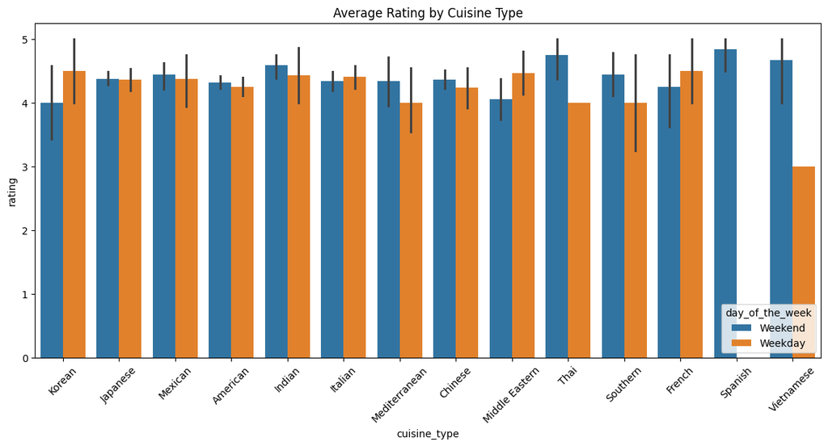

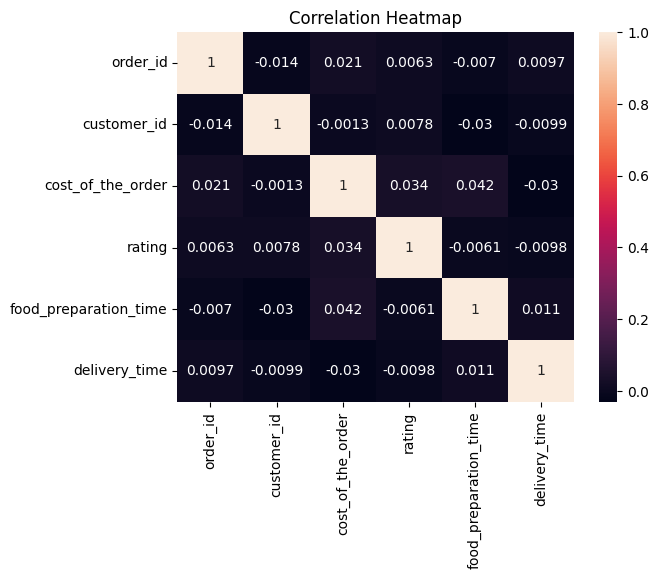

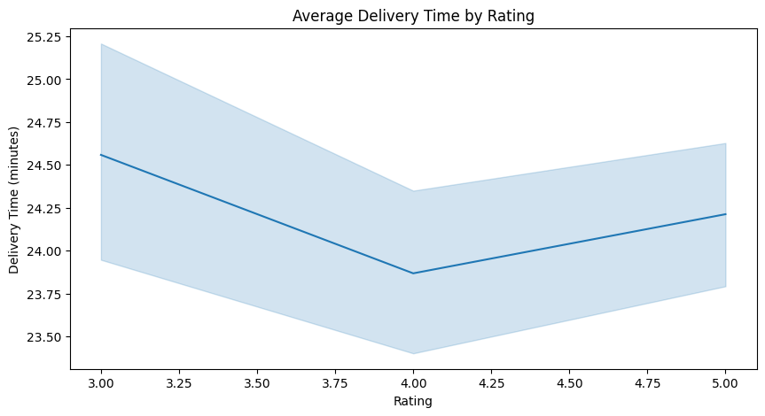

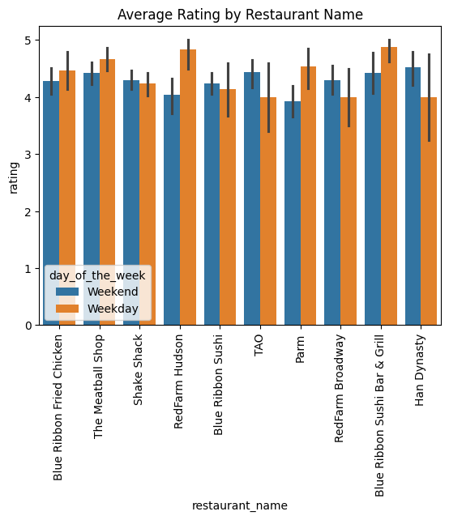

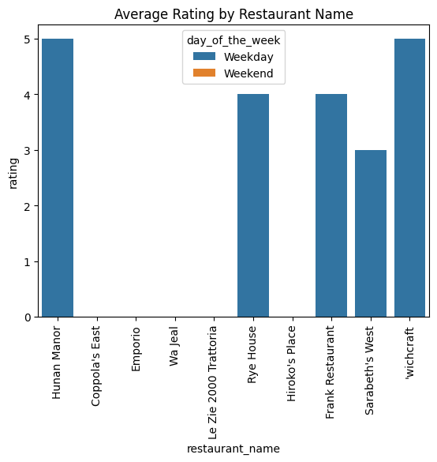

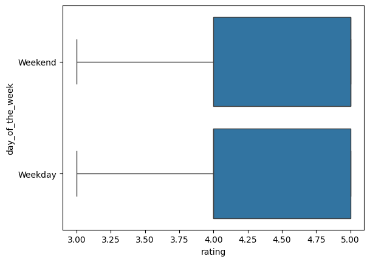

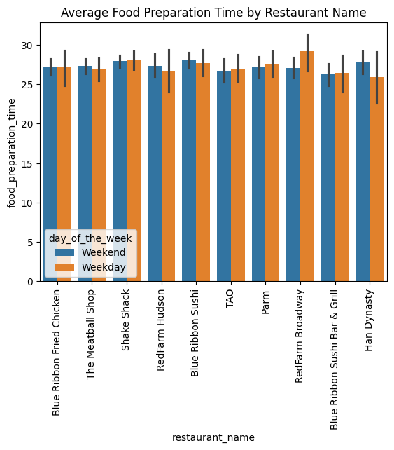

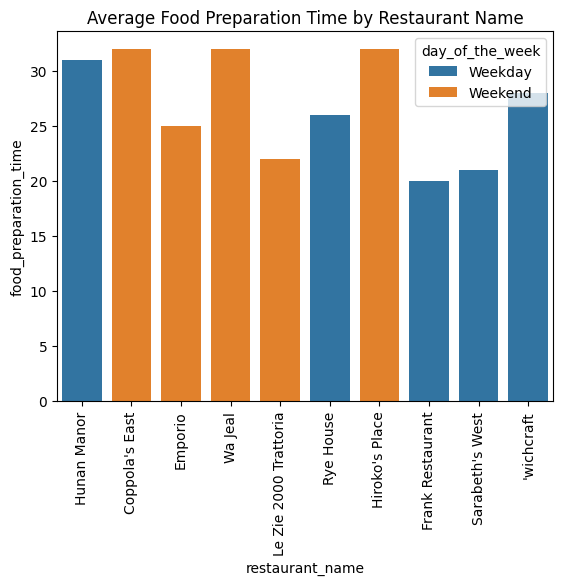

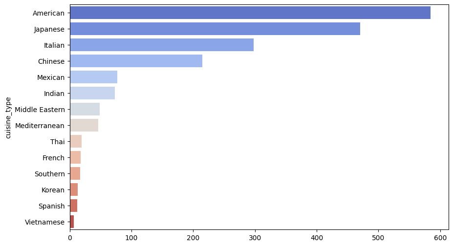

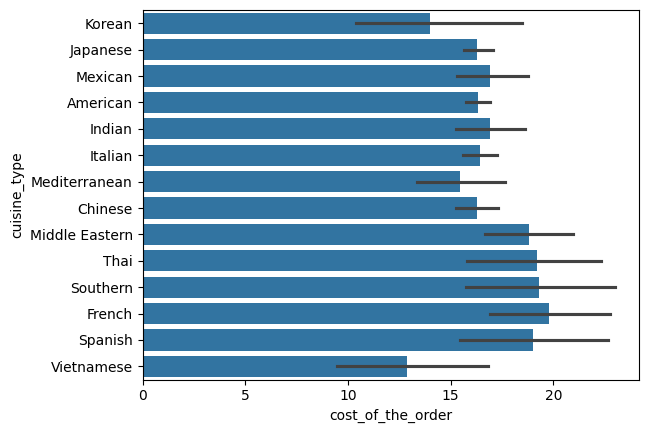

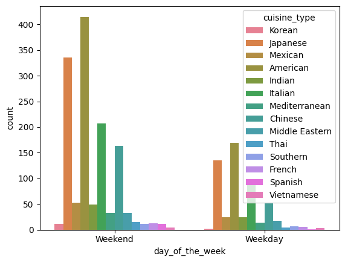

```python
# Write the code here
df['rating'] = df['rating'].replace('Not given', np.nan)
df['rating'] = pd.to_numeric(df['rating'])
df.info()
#praveen rating is my target column
#praveen checking which cuisine_type vs rating people rate more Spanish, Thai, and Indian cuisines received the highest average ratings, suggesting these are the most well-liked by customers.
#On the other hand, Vietnamese and Korean cuisines have relatively lower average ratings, indicating slightly lower customer satisfaction compared to other cuisines.
#Rating - food_preparation_time -> numerical -> invalid
#Rating - delivery_time -> numerical -> vaild. -> done
#rating - cost_of_the_order -> numerical -> invalid/vaild
#Rating - cuisine_type -> num-categorical -> vaild  -> done
#rating - day_of_the_week -> num-categorical -> vaild ->
#rating - restaurant_name -> num-categorical  -> vaild. -> done
plt.figure(figsize=(14, 6))
sns.barplot(data=df, x='cuisine_type', y='rating', hue='day_of_the_week')
plt.xticks(rotation=45)
plt.title("Average Rating by Cuisine Type")
plt.show()
# praveen checking heat map for all numerical columns.

sns.heatmap(df.corr(numeric_only=True), annot=True)
plt.title("Correlation Heatmap")
plt.show()

#line plot between rating and delivery_time
plt.figure(figsize=(10, 5))
sns.lineplot(data=df, x='rating', y='delivery_time')
plt.title("Average Delivery Time by Rating")
plt.xlabel("Rating")
plt.ylabel("Delivery Time (minutes)")
plt.show()

#plot between rating - restaurant_name
#take top 10 restarunt name
top_restaurants = df['restaurant_name'].value_counts().head(10).index
df_top = df[df['restaurant_name'].isin(top_restaurants)]
df_top.shape
low_restaurants = df['restaurant_name'].value_counts().tail(10).index
df_low = df[df['restaurant_name'].isin(low_restaurants)]
df_low.shape
#rating vs hotel ->check the ratings for the top 10 restaurant with maximum orders,
#Top 10 hotels with more orders rating:RedFram Hudson  - weekday - close to 5, weekends below 4.5
#Least 10 hotels:Though most of the hotels there is no rating at all but
#Hunan Manor and witchcraft has very close to 5 ratings during weekdays.
sns.barplot(data=df_top, x='restaurant_name', y='rating', hue='day_of_the_week')
plt.xticks(rotation=90)
plt.title("Average Rating by Restaurant Name")
plt.show()
#
sns.barplot(data=df_low, x='restaurant_name', y='rating', hue='day_of_the_week')
plt.xticks(rotation=90)
plt.title("Average Rating by Restaurant Name")
plt.show()

#rating vs day_of_the_week -> The median rating appears to be around 4.0 for both weekdays and weekends.  Generally customers are happy on othe category.
sns.boxplot(data=df,x='rating',y='day_of_the_week')
plt.show()

#top hotel vs food preparation time.
sns.barplot(data=df_top, x='restaurant_name', y='food_preparation_time', hue='day_of_the_week')
plt.xticks(rotation=90)
plt.title("Average Food Preparation Time by Restaurant Name")
plt.show()
#low hotel vs food preparation time.
sns.barplot(data=df_low, x='restaurant_name', y='food_preparation_time', hue='day_of_the_week')
plt.xticks(rotation=90)
plt.title("Average Food Preparation Time by Restaurant Name")
plt.show()

order_counts_by_cuisine = df['cuisine_type'].value_counts()

#Number of Orders per Cuisine Type
plt.figure(figsize=(10, 6))
sns.barplot(x=order_counts_by_cuisine.values, y=order_counts_by_cuisine.index, palette="coolwarm")
plt.show();

sns.barplot(data=df, x='cost_of_the_order', y='cuisine_type')
plt.show()
sns.countplot(data=df, x='day_of_the_week', hue='cuisine_type')
plt.show()

#
```

### **Question 13:** The company wants to provide a promotional offer in the advertisement of the restaurants. The condition to get the offer is that the restaurants must have a rating count of more than 50 and the average rating should be greater than 4. Find the restaurants fulfilling the criteria to get the promotional offer. [3 marks]

```python
# Write the code here

rating_count = df.groupby('restaurant_name')['rating'].count()
rating_mean = df.groupby('restaurant_name')['rating'].mean()

rating_count_filter = rating_count>50
rating_mean_filter = rating_mean>4

final_filter = rating_count_filter & rating_mean_filter
final_filter
eligible_restaurants = rating_count.index[final_filter]
eligible_restaurants
```

```
Index(['Blue Ribbon Fried Chicken', 'Blue Ribbon Sushi', 'Shake Shack',
       'The Meatball Shop'],
      dtype='object', name='restaurant_name')
```

# Observations:

The following restaurants qualify for the promotional offer: **Blue Ribbon Fried Chicken, Blue Ribbon Sushi, Shake Shack, The Meatball Shop**

### **Question 14:** The company charges the restaurant 25% on the orders having cost greater than 20 dollars and 15% on the orders having cost greater than 5 dollars. Find the net revenue generated by the company across all orders. [3 marks]

```python
# Write the code here
conditions =[
    df['cost_of_the_order']>20,
    (df['cost_of_the_order']>5) & (df['cost_of_the_order']<=20)
]

choices = [
    df['cost_of_the_order']*0.25,
    df['cost_of_the_order']*0.15
]

df['revenue'] = np.select(conditions, choices, default=0)
net_revenue = df['revenue'].sum()
print(net_revenue)
```

```
6166.303
```

#### Observations:

the net revenue generated by the company across all orders is **$6166.303**

### **Question 15:** The company wants to analyze the total time required to deliver the food. What percentage of orders take more than 60 minutes to get delivered from the time the order is placed? (The food has to be prepared and then delivered.) [2 marks]

```python
# Write the code here
df['total_time'] = df['food_preparation_time'] + df['delivery_time']
over_60 = df[df['total_time'] > 60].shape[0]
total_orders = df.shape[0]
precentage = (200/total_orders)*100
precentage
```

```
10.537407797681771
```

#### Observations:

only 10.54 percentage of orders takes more than 60 minutes to get delivered from the time the order is placed. which is good sign and indicates good performance for food delivery.

### **Question 16:** The company wants to analyze the delivery time of the orders on weekdays and weekends. How does the mean delivery time vary during weekdays and weekends? [2 marks]

```python
# Write the code here
mean_delivery_time = df.groupby('day_of_the_week')['delivery_time'].mean()
print(mean_delivery_time)
difference = mean_delivery_time['Weekday'] - mean_delivery_time['Weekend']
difference
```

```
day_of_the_week
Weekday    28.340037
Weekend    22.470022
Name: delivery_time, dtype: float64
```

```
np.float64(5.870014357297798)
```

#### Observations:

Weekday average delivery time : 28.34 minutes weekend average delivery time : 22.47 minutes The variation in delivery_time during weekdays and weekends is **5.87**. which means Weekday delivery times are 5.87 minutes longer than on weekends, that could be because of the traffic during business days.